# Project : EDA on Earthquakes in Japan

## Importing libraries

```python
import pandas as pd
pd.set_option('display.max_columns', None)
import numpy as np
import matplotlib as mpl
import matplotlib.pyplot as plt
import folium
import seaborn as sns
from sklearn.cluster import KMeans
print('LIABRARY IMPORT SUCCESS.')
```

```
LIABRARY IMPORT SUCCESS.
```

## Why Japan?

because it has been one of the most earthquake prone regions in the world in history. https://www.usgs.gov/faqs/which-country-has-most-earthquakes? so it makes sense to study earthquakes in japan and what factors affect it.

```python
df = pd.read_csv("Japan earthquakes 2001 - 2018.csv")
df
```

|  | time | latitude | longitude | depth | mag | magType | nst | gap | dmin | rms | net | id | updated | place | type | horizontalError | depthError | magError | magNst | status | locationSource | magSource |
| --- | --- | --- | --- | --- | --- | --- | --- | --- | --- | --- | --- | --- | --- | --- | --- | --- | --- | --- | --- | --- | --- | --- |
| 0 | 2018-11-27T14:34:20.900Z | 48.3780 | 154.9620 | 35.00 | 4.9 | mb | NaN | 92.0 | 5.044 | 0.63 | us | us1000hx1b | 2018-11-27T16:06:33.040Z | 269km SSW of Severo-Kuril'sk, Russia | earthquake | 7.6 | 1.7 | 0.036 | 248.0 | reviewed | us | us |
| 1 | 2018-11-26T23:33:50.630Z | 36.0733 | 139.7830 | 48.82 | 4.8 | mww | NaN | 113.0 | 1.359 | 1.13 | us | us1000hwvf | 2018-11-27T16:44:22.223Z | 3km SSW of Sakai, Japan | earthquake | 6.0 | 6.1 | 0.071 | 19.0 | reviewed | us | us |
| 2 | 2018-11-26T13:04:02.250Z | 38.8576 | 141.8384 | 50.56 | 4.5 | mb | NaN | 145.0 | 1.286 | 0.84 | us | us1000hwmi | 2018-11-26T23:52:21.074Z | 26km SSE of Ofunato, Japan | earthquake | 8.4 | 9.5 | 0.156 | 12.0 | reviewed | us | us |
| 3 | 2018-11-26T05:20:16.440Z | 50.0727 | 156.1420 | 66.34 | 4.6 | mb | NaN | 128.0 | 3.191 | 0.62 | us | us1000hwkm | 2018-11-26T08:13:58.040Z | 67km S of Severo-Kuril'sk, Russia | earthquake | 9.7 | 7.8 | 0.045 | 151.0 | reviewed | us | us |
| 4 | 2018-11-25T09:19:05.010Z | 33.9500 | 134.4942 | 38.19 | 4.6 | mb | NaN | 104.0 | 0.558 | 0.61 | us | us1000hwig | 2018-11-25T23:24:52.615Z | 9km SW of Komatsushima, Japan | earthquake | 3.4 | 10.1 | 0.132 | 17.0 | reviewed | us | us |
| ... | ... | ... | ... | ... | ... | ... | ... | ... | ... | ... | ... | ... | ... | ... | ... | ... | ... | ... | ... | ... | ... | ... |
| 14087 | 2001-01-04T04:18:21.430Z | 36.9810 | 138.6290 | 21.40 | 5.3 | mwc | 240.0 | NaN | NaN | 0.78 | us | usp000a74c | 2016-11-09T21:35:38.927Z | eastern Honshu, Japan | earthquake | NaN | 5.4 | NaN | NaN | reviewed | us | hrv |
| 14088 | 2001-01-03T14:47:49.540Z | 43.9320 | 147.8130 | 33.00 | 5.9 | mwc | 362.0 | NaN | NaN | 0.82 | us | usp000a73r | 2016-11-09T04:09:27.754Z | Kuril Islands | earthquake | NaN | NaN | NaN | NaN | reviewed | us | hrv |
| 14089 | 2001-01-03T09:32:54.710Z | 45.3010 | 149.9410 | 33.00 | 4.6 | mb | 40.0 | NaN | NaN | 0.82 | us | usp000a73h | 2014-11-07T01:11:51.270Z | Kuril Islands | earthquake | NaN | NaN | NaN | 20.0 | reviewed | us | us |
| 14090 | 2001-01-02T20:29:49.670Z | 32.2390 | 141.5080 | 33.00 | 4.9 | mb | 32.0 | NaN | NaN | 0.96 | us | usp000a72u | 2014-11-07T01:11:51.119Z | Izu Islands, Japan region | earthquake | NaN | NaN | NaN | 23.0 | reviewed | us | us |
| 14091 | 2001-01-02T10:53:23.280Z | 37.2180 | 138.4310 | 33.00 | 4.9 | mb | 43.0 | NaN | NaN | 0.93 | us | usp000a72e | 2014-11-07T01:11:50.950Z | near the west coast of Honshu, Japan | earthquake | NaN | NaN | NaN | 15.0 | reviewed | us | us |

14092 rows × 22 columns

```python
# Just a quick shortcut to do statistical analysis. TO see how values vary.
df.describe()
```

|  | latitude | longitude | depth | mag | nst | gap | dmin | rms | horizontalError | depthError | magError | magNst |
| --- | --- | --- | --- | --- | --- | --- | --- | --- | --- | --- | --- | --- |
| count | 14092.000000 | 14092.000000 | 14092.000000 | 14092.000000 | 10483.000000 | 13310.000000 | 3607.000000 | 14014.000000 | 2800.000000 | 9040.000000 | 3431.000000 | 11048.000000 |
| mean | 37.410294 | 142.980441 | 51.364838 | 4.817045 | 117.352094 | 104.272149 | 2.359796 | 0.876561 | 7.288607 | 7.822920 | 0.095182 | 48.590695 |
| std | 6.605873 | 6.552510 | 76.603810 | 0.378618 | 123.273889 | 37.893474 | 1.658681 | 0.203787 | 2.263028 | 5.861948 | 0.060710 | 70.233727 |
| min | 23.532900 | 124.293000 | 0.000000 | 4.500000 | 5.000000 | 8.000000 | 0.038000 | 0.120000 | 1.400000 | 0.000000 | 0.019000 | 1.000000 |
| 25% | 33.147675 | 141.071000 | 14.400000 | 4.600000 | 36.000000 | 78.000000 | 1.109000 | 0.740000 | 5.800000 | 4.400000 | 0.054000 | 9.000000 |
| 50% | 37.357000 | 142.452100 | 35.000000 | 4.700000 | 69.000000 | 112.700000 | 1.979000 | 0.850000 | 7.100000 | 6.200000 | 0.079000 | 23.000000 |
| 75% | 42.271325 | 144.432000 | 50.372500 | 4.900000 | 153.000000 | 130.900000 | 3.122500 | 0.990000 | 8.500000 | 9.600000 | 0.118000 | 57.000000 |
| max | 50.816100 | 158.818000 | 683.360000 | 9.100000 | 929.000000 | 306.600000 | 18.781000 | 1.880000 | 25.600000 | 70.700000 | 0.555000 | 941.000000 |

```python
print('No. of rows in dataset:',df.shape[0],"\nNo. of columns in dataset:",df.shape[1])

df['time'] = pd.to_datetime(df['time'])
df['updated'] = pd.to_datetime(df['updated'])

# Datatypes of all the columns.
print('\nData and their types: \n', df.dtypes)
```

```
No. of rows in dataset: 14092
No. of columns in dataset: 22

Data and their types:
 time               datetime64[ns, UTC]
latitude                       float64
longitude                      float64
depth                          float64
mag                            float64
magType                         object
nst                            float64
gap                            float64
dmin                           float64
rms                            float64
net                             object
id                              object
updated            datetime64[ns, UTC]
place                           object
type                            object
horizontalError                float64
depthError                     float64
magError                       float64
magNst                         float64
status                          object
locationSource                  object
magSource                       object
dtype: object
```

## Cleaning the dataset and encoding categorical values.

## Let's Take a look at the dataframe:

Let's take a look at each of the column of the dataframe and decide which of the columns we don't require for the analysis.

From the dataframe let's take into notice, the references by the columns.

| Serial Number: | Column Header: | Refernce by the column |
| --- | --- | --- |
| 01. | time | Time of the earthquake event |
| 02. | latitude | Latitude of the recorded event |
| 03. | longitude | Longitude of the recorde event |
| 04. | depth | The depth where the earthquake begins to rupture |
| 05. | mag | Magnitude of the event recorded. |
| 06. | magType | The method or algorithm used to calculate the preferred magnitude for the event |
| 07. | nst | The total number of seismic stations used to determine earthquake location |
| 08. | gap | The largest azimuthal gap between azimuthally adjacent stations (in degrees) |
| 09. | rms | The root-mean-square (RMS) travel time residual, in sec, using all weights |
| 10. | id | A unique identifier for the event. |
| 11. | updated | Time when the event was most recently updated. |
| 12. | place | Textual description of named geographic region near to the event. |
| 13. | type | Type of the incident recorded. |
| 14. | horizontalError | Uncertainty of reported location of the event in kilometers |
| 15. | depthError | Uncertainty of reported depth of the event in kilometers |
| 16. | magError | Uncertainty of reported magnitude of the event |
| 17. | magNst | The total number of seismic stations used to calculate the magnitude for this earthquake |
| 18. | status | Status of the recorded event. |
| 19. | dmin | Horizontal distance from the epicenter to the nearest station (in degrees) |
| 20. | locationSource | The network that originally authored the reported location of this event |
| 21. | magSource | The network that originally authored the reported magnitude of the event. |

We don't require magtype,id,etc. like columns .So dropping unwanted columns,

```python
df.drop(['magType', 'id', 'magSource', 'locationSource', 'net'], axis = 1, inplace = True)
df.head()
```

|  | time | latitude | longitude | depth | mag | nst | gap | dmin | rms | updated | place | type | horizontalError | depthError | magError | magNst | status |
| --- | --- | --- | --- | --- | --- | --- | --- | --- | --- | --- | --- | --- | --- | --- | --- | --- | --- |
| 0 | 2018-11-27 14:34:20.900000+00:00 | 48.3780 | 154.9620 | 35.00 | 4.9 | NaN | 92.0 | 5.044 | 0.63 | 2018-11-27 16:06:33.040000+00:00 | 269km SSW of Severo-Kuril'sk, Russia | earthquake | 7.6 | 1.7 | 0.036 | 248.0 | reviewed |
| 1 | 2018-11-26 23:33:50.630000+00:00 | 36.0733 | 139.7830 | 48.82 | 4.8 | NaN | 113.0 | 1.359 | 1.13 | 2018-11-27 16:44:22.223000+00:00 | 3km SSW of Sakai, Japan | earthquake | 6.0 | 6.1 | 0.071 | 19.0 | reviewed |
| 2 | 2018-11-26 13:04:02.250000+00:00 | 38.8576 | 141.8384 | 50.56 | 4.5 | NaN | 145.0 | 1.286 | 0.84 | 2018-11-26 23:52:21.074000+00:00 | 26km SSE of Ofunato, Japan | earthquake | 8.4 | 9.5 | 0.156 | 12.0 | reviewed |
| 3 | 2018-11-26 05:20:16.440000+00:00 | 50.0727 | 156.1420 | 66.34 | 4.6 | NaN | 128.0 | 3.191 | 0.62 | 2018-11-26 08:13:58.040000+00:00 | 67km S of Severo-Kuril'sk, Russia | earthquake | 9.7 | 7.8 | 0.045 | 151.0 | reviewed |
| 4 | 2018-11-25 09:19:05.010000+00:00 | 33.9500 | 134.4942 | 38.19 | 4.6 | NaN | 104.0 | 0.558 | 0.61 | 2018-11-25 23:24:52.615000+00:00 | 9km SW of Komatsushima, Japan | earthquake | 3.4 | 10.1 | 0.132 | 17.0 | reviewed |

### Replacing the Null Values with means

Let's replace the null values with the average of the column from the dataset. This process is more reliable than dropping the null data altogether.This will result in a cleaner data

```python
df.fillna(df.mean(), inplace = True)
df.head()
```

[output not shown]

### Removing the non earthquake data

Some data was from nuclear explosions and I removed them so our analysis doesn't gets affected.

```python
print(df['type'].value_counts())
print(df['status'].value_counts())
```

```
earthquake           14087
nuclear explosion        5
Name: type, dtype: int64
reviewed     14091
automatic        1
Name: status, dtype: int64
```

```python
df['type'] = df['type'].apply(lambda x:1 if (x =='earthquake') else 0)
df['status'] = df['status'].apply(lambda x:1 if (x =='reviewed') else 0)

#only keeping those values in df where the data is from earthquake and not from nuclear explosion
earth_quake_encoded = df[df.type != 0]
print(df.head(5))

#deleting type column after this.
earth_quake_encoded.drop(['type'], axis = 1, inplace = True)
```

[output not shown]

[output cut: 19 more lines]

## Plotting the data on Map using folium

```python
from folium.plugins import MarkerCluster
from folium.plugins import FastMarkerCluster
quake_map = folium.Map(location=[earth_quake_encoded['latitude'].mean(),
                                earth_quake_encoded['longitude'].mean()],
                                zoom_start=5)

quake_map.add_child(FastMarkerCluster(earth_quake_encoded[['latitude', 'longitude']].values.tolist()))
quake_map
```

Make this Notebook Trusted to load map: File -> Trust Notebook

[interactive chart not shown]

```python
#For setting the default plotting size
import matplotlib.pyplot as plt
plt.rcParams["figure.figsize"] = (10,8)
plt.rcParams.update({'font.size': 16})
```

## Examining relationship between variables

Let's visually represent the relationship among the different values of the dataset. We will examine the variables both in 2-Dimensional and 3-Dimensional form factors.

Nature can't be predicted perfectly. So, we will see irregularities in the data visualisations supporting the unpredictiveness of Nature and its elements.

### 1. Scatter Plot between Depth and Magnitude

Here Depth is the depth where the earthquake begins to rupture and Magnitude is magnitude of the earthquake.

The Scatter plot between depth and magnitude does not yeild any kind of relationship among the two prefectly. But we can analyse a linear data between the two.

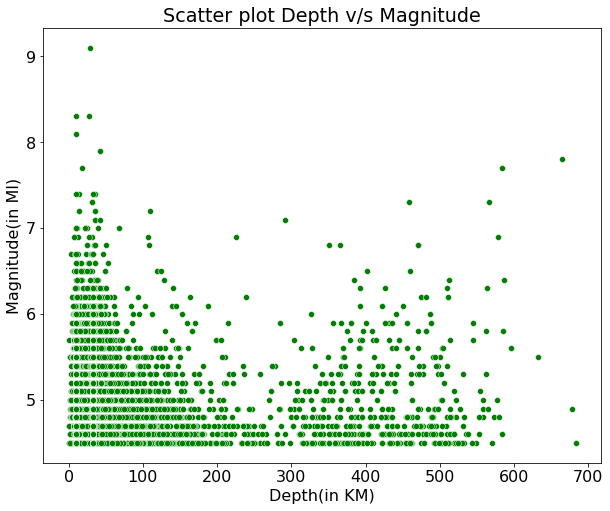

```python
sns.scatterplot(x= earth_quake_encoded['depth'].values, y=earth_quake_encoded['mag'].values, data = earth_quake_encoded, color = 'green')
plt.xlabel('Depth(in KM)')
plt.ylabel('Magnitude(in Ml)')
plt.title("Scatter plot Depth v/s Magnitude")
plt.show()

plt.savefig("fig1.png")
```

### Regression plot between Depth and Magnitude:

The regression plot between the depth and the magnitude values shows a linear relationship between the two. As the data is clustered at the start the deviation in the line(denoted by shading) is less while it increases with the value of depth as the data becomes uncertain

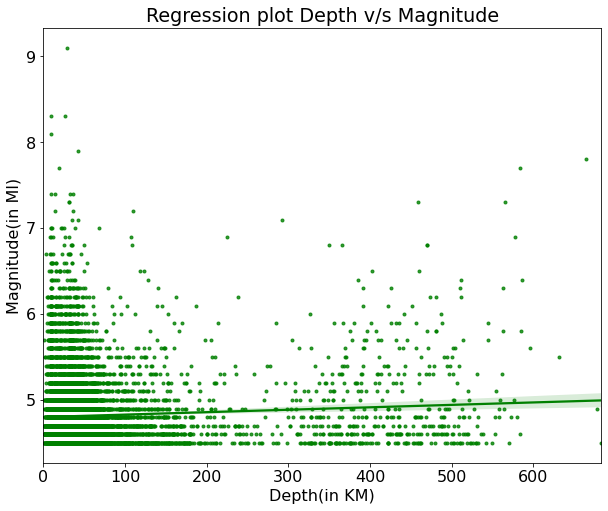

```python
reg_plot_depth_mag = pd.DataFrame(columns =['Depth', 'Magnitude'])
reg_plot_depth_mag['Depth'] = earth_quake_encoded['depth'].values
reg_plot_depth_mag['Magnitude'] = earth_quake_encoded['mag'].values
sns.regplot(x=reg_plot_depth_mag['Depth'], y = reg_plot_depth_mag['Magnitude'], data = reg_plot_depth_mag, color = 'green',marker=".")
plt.xlabel('Depth(in KM)')
plt.ylabel('Magnitude(in Ml)')
plt.title("Regression plot Depth v/s Magnitude")
plt.savefig("fig2.png")
```

### 2. Scatter Plot and Regression Plot between Number of station required to measure the event versus magnitude

As we can see, there seems like a relationship between these two variables , however that is a human error as the magnitude of the earthquake should not depend upon the no. of stations used to detect siesmic activities

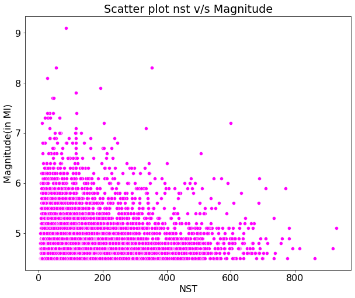

```python
reg_plot_depth_mag['NST'] = earth_quake_encoded['nst']
plt.ylabel('Magnitude(in Ml)')
plt.title("Scatter plot nst v/s Magnitude")
sns.scatterplot(x= reg_plot_depth_mag['NST'], y = reg_plot_depth_mag['Magnitude'], data = reg_plot_depth_mag, color = 'magenta')

plt.savefig("fig3.png")
```

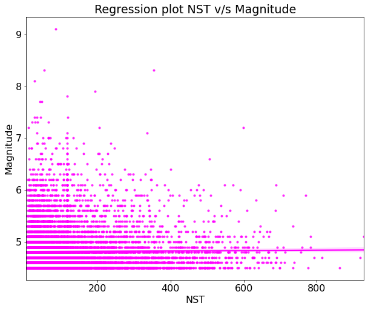

```python
plt.ylabel('Magnitude(in Ml)')
plt.title("Regression plot NST v/s Magnitude")
sns.regplot(x=reg_plot_depth_mag['NST'], y = reg_plot_depth_mag['Magnitude'], data = reg_plot_depth_mag, color = 'magenta',marker=".")

plt.savefig("fig4.png")
```

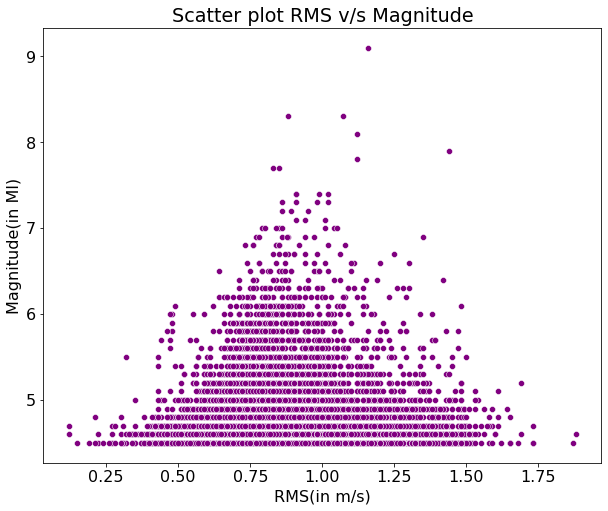

```python
sns.scatterplot(x= earth_quake_encoded['rms'], y= earth_quake_encoded['mag'], data = earth_quake_encoded, color = 'purple',marker="o")
plt.xlabel('RMS(in m/s)')
plt.ylabel('Magnitude(in Ml)')
plt.title("Scatter plot RMS v/s Magnitude")

plt.savefig("fig5.png")
```

### 4. Regression plot between the horizontal distance of the recorded place with the depth of the rupture of the waves.

The regression plot shows a large amount of deviation meaning that the relationship among the two is not linear.

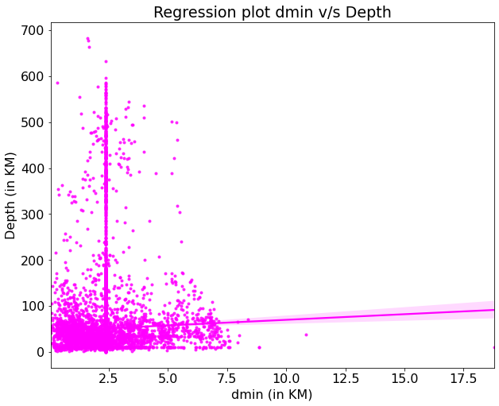

```python
sns.regplot(x= earth_quake_encoded['dmin'], y = earth_quake_encoded['depth'], data = earth_quake_encoded, color = 'magenta',marker=".")
plt.xlabel('dmin (in KM)')
plt.ylabel('Depth (in KM)')
plt.title("Regression plot dmin v/s Depth")

plt.savefig("fig6.png")
```

### 5. Regression plot between the horizontal distance and the magnitude:

The regression plot between the horizontal distance from the epicenter and the magnitude shows a linear regression plot but with higer deviations, basically implying non-linearity between the two variables.

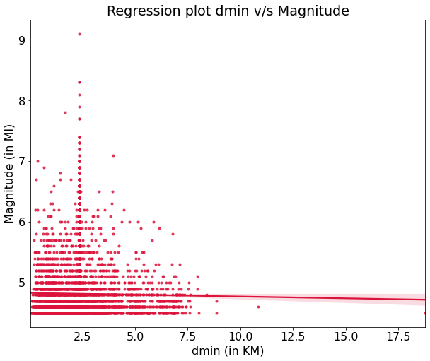

```python
sns.regplot(x= earth_quake_encoded['dmin'], y = earth_quake_encoded['mag'], data = earth_quake_encoded, color = 'crimson',marker=".")
plt.xlabel('dmin (in KM)')
plt.ylabel('Magnitude (in Ml)')
plt.title("Regression plot dmin v/s Magnitude")

plt.savefig("fig7.png")
```

### 6. Regression plot between azimuthal gap versus magnitude:

On the other hand the negative regression signifies a linear regression relationship between magnitude and the azimuthal gap.

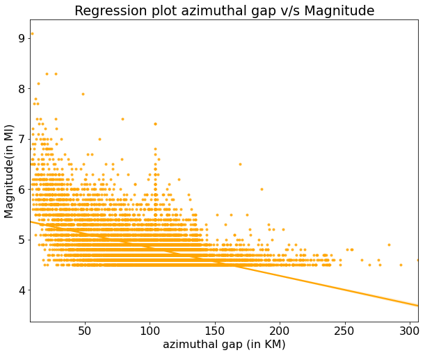

```python
sns.regplot(x= earth_quake_encoded['gap'], y = earth_quake_encoded['mag'], data = earth_quake_encoded, color = 'orange',marker=".")
plt.xlabel('azimuthal gap (in KM)')
plt.ylabel('Magnitude(in Ml)')
plt.title("Regression plot azimuthal gap v/s Magnitude")
plt.savefig("fig8.png")
```

### 7. Regression Plot between error in measuring magnitude:

This plot shows a negative linear regression with a minimal deviation, referring that, if the error in measuring the magnitude increases, the magnitude decreases. This is true and just basically verifying the data in the column.

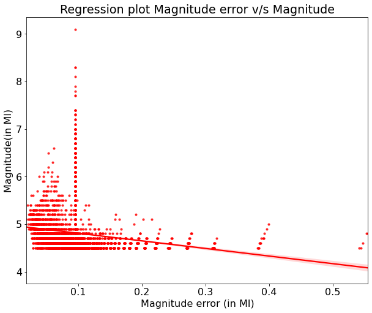

```python
sns.regplot(x = earth_quake_encoded['magError'], y=earth_quake_encoded['mag'], color = 'red',marker=".")
plt.xlabel('Magnitude error (in Ml)')
plt.ylabel('Magnitude(in Ml)')
plt.title("Regression plot Magnitude error v/s Magnitude")

plt.savefig("fig9.png")
```

### 8. Time vs magnitude plots or time series plots.

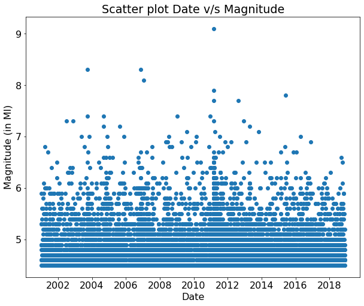

```python
time_vs_mag_bar = pd.DataFrame(columns = {'time', 'mag'})
time_vs_mag_bar['time'] = earth_quake_encoded['time']
time_vs_mag_bar['mag'] = earth_quake_encoded['mag']

#saving the data just for studying it differently.
time_vs_mag_bar.to_csv('time_vs_mag.csv',index=False)

dates = mpl.dates.date2num(time_vs_mag_bar['time'].values)
plt.plot_date(dates, time_vs_mag_bar['mag'])
plt.ylabel('Magnitude (in Ml)')
plt.xlabel('Date')
plt.title("Scatter plot Date v/s Magnitude")


plt.savefig("fig11.png")
```

**from the below plot we can see that japan has been heavily affected by earthquakes in the entire period but peak magnitude was reached in 2011 ofcourse due to massive tokohu earthquake**

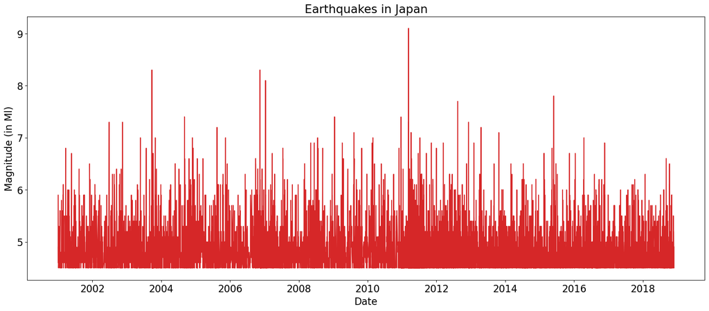

```python
def plot_df( x, y, title="", xlabel='Date', ylabel='Magnitude (in Ml)', dpi=100):
    plt.figure(figsize=(20,8), dpi=dpi)
    plt.plot(x, y, color='tab:red')
    plt.gca().set(title=title, xlabel=xlabel, ylabel=ylabel)
    plt.show()

df = pd.read_csv('time_vs_mag.csv', parse_dates=['time'], index_col='time')
plot_df(x=df.index.date, y=df["mag"], title='Earthquakes in Japan')

plt.savefig("fig12.png")
```

### 3 Dimensional Visualisation of Depth vs. Root Mean Square Speed vs. Magnitude

Here we plot Depth in the X-Axis, Root Mean Square Speed in the Y-Axis and Magnitude of the recorded event in the Z-Axis to obtain a 3 dimensional plot for better understanding the realtionship between the varaiables

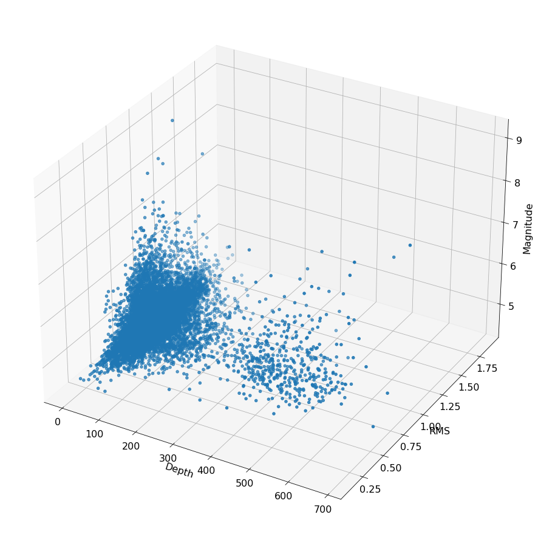

```python
from mpl_toolkits.mplot3d import Axes3D
fig = plt.figure(figsize = (16, 16))
ax = fig.add_subplot(111, projection = '3d')
ax.set_xlabel('Depth')
ax.set_ylabel('RMS')
ax.set_zlabel('Magnitude')
ax.scatter(earth_quake_encoded['depth'], earth_quake_encoded['rms'], earth_quake_encoded['mag'])
plt.show()
plt.savefig("fig13.png")
```

### 3 Dimensional Visualisation of Gap vs. Number of Station Required vs. Magnitude.

Here we plot Gap in the X-Axis, number of stations required in the Y-Axis and Magnitude of the recorded event in the Z-Axis to obtain a 3 dimensional plot for better understanding the realtionship between the varaiables.

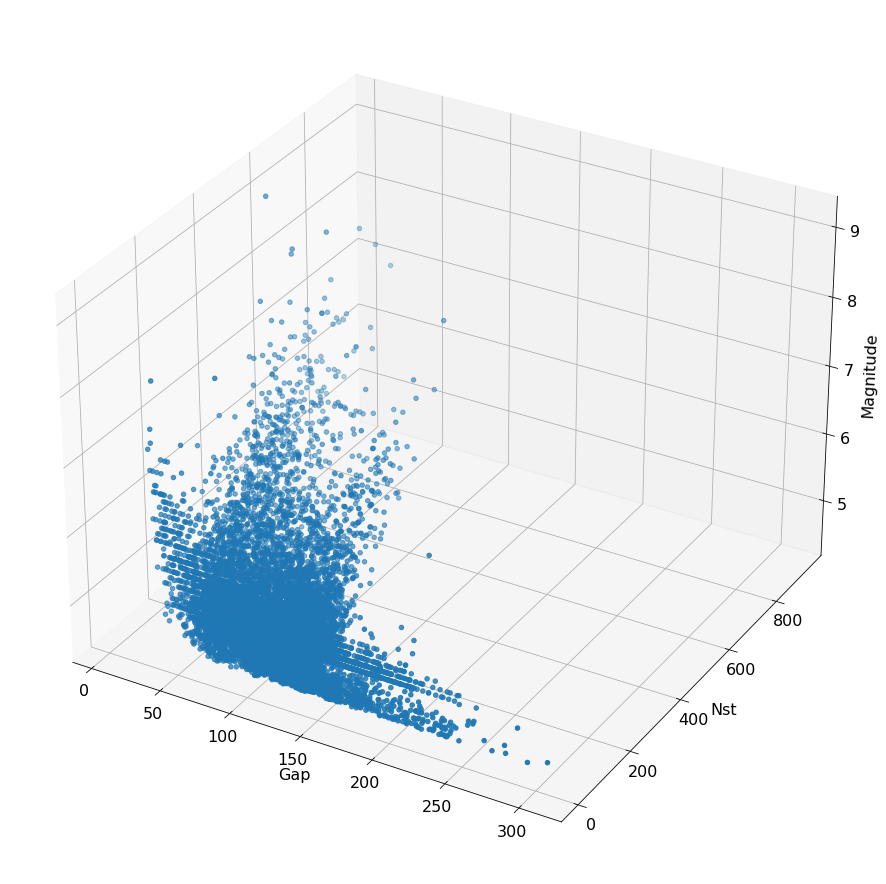

```python
fig = plt.figure(figsize = (16, 16))
ax = fig.add_subplot(111, projection = '3d')
ax.scatter(earth_quake_encoded['gap'],earth_quake_encoded['nst'],earth_quake_encoded['mag'])
ax.set_xlabel('Gap')
ax.set_ylabel('Nst')
ax.set_zlabel('Magnitude')
plt.show()

plt.savefig("fig14.png")
```

### Folium heatmap for earthquakes in japan

The map gradients kind of block the regions but we can see that almost all of japan is heavily affected by earthquakes

```python
heat_quake_map = folium.Map(location=[earth_quake_encoded['latitude'].mean(),
                                earth_quake_encoded['longitude'].mean()],
                                zoom_start=4)
latlons = earth_quake_encoded[['latitude', 'longitude']].values.tolist()
from folium.plugins import HeatMap
HeatMap(latlons).add_to(heat_quake_map)
heat_quake_map
```

Make this Notebook Trusted to load map: File -> Trust Notebook

[interactive chart not shown]

## Plotting a horizontal bar graph to identify top 20 most Earthquake prone regions.

```python
# Place column has named locations of the earthquake regions
earth_quake_encoded["place"]
```

```
0        269km SSW of Severo-Kuril'sk, Russia
1                     3km SSW of Sakai, Japan
2                  26km SSE of Ofunato, Japan
3           67km S of Severo-Kuril'sk, Russia
4               9km SW of Komatsushima, Japan
                         ...
14087                   eastern Honshu, Japan
14088                           Kuril Islands
14089                           Kuril Islands
14090               Izu Islands, Japan region
14091    near the west coast of Honshu, Japan
Name: place, Length: 14087, dtype: object
```

#### manipulating dataframe to get 20 regions

```python
count = earth_quake_encoded['place'].value_counts()
count
usa_top_earthquakes_df = count.rename_axis('place').reset_index(name='Earthquake Count')
usa_top_earthquakes_df

#Let's Select top 20 places
usa_top = usa_top_earthquakes_df[0:20]
print(usa_top)
print(usa_top_earthquakes_df.shape)
fetcher = earth_quake_encoded.set_index('place')
fetched = fetcher.loc[usa_top['place'], ['latitude', 'longitude']]
latitude_to_search = fetched['latitude']
longitude_to_search = fetched['longitude']
```

```
                                            place  Earthquake Count
0             off the east coast of Honshu, Japan              2344
1            near the east coast of Honshu, Japan              2141
2                                   Kuril Islands              1789
3                     Bonin Islands, Japan region               858
4                       Izu Islands, Japan region               617
5                       east of the Kuril Islands               613
6                          Hokkaido, Japan region               557
7                           Ryukyu Islands, Japan               384
8                           eastern Honshu, Japan               249
9                   Volcano Islands, Japan region               132
10          near the south coast of Honshu, Japan               114
11                                  Kyushu, Japan               108
12           near the west coast of Honshu, Japan                93
13                               Sakhalin, Russia                55
14             southwestern Ryukyu Islands, Japan                55
15  near the south coast of western Honshu, Japan                50
16                            northeast of Taiwan                45
17            Off the east coast of Honshu, Japan                44
18                                   Sea of Japan                35
19                      East of the Kuril Islands                33
(3211, 2)
```

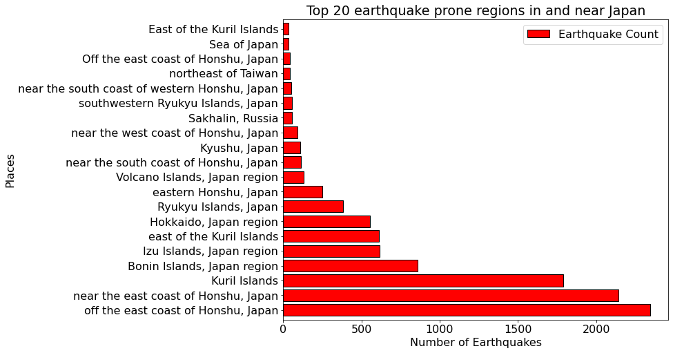

```python
plotter = usa_top.set_index('place')
plt.figure(figsize = (20,10))
plotter.plot(kind = 'barh', width = 0.8, color = 'red', edgecolor = 'black')
plt.xlabel("Number of Earthquakes")
plt.ylabel("Places")
plt.title("Top 20 earthquake prone regions in and near Japan")
plt.show()

plt.savefig("fig15.png")
```

## Conclusion

**During this project I studied how earthquakes affect Japan and which regions it affect the most.**

**I plan to use a MAP api to connect with the dataset to identify hotels and other public places which are potentially earthquake prone .**